# R Programming project

Maria Yasin

## PART 1 (ANALYSIS)

### Dataset

I am using the health data set “GPA05 - Costs of Patients”, originally published by the Central Statistics Office (CSO). I extracted the data set from Data.gov.ie. The data set can be accessed via the link below:

https://data.gov.ie/dataset/gpa05-costs-of-patients?package_type=dataset

The data set was last updated on 18-09-2020. It looks at the annual cost of patients (in millions) in Ireland over a span of 5 years (2013-2017). It contains a categorical variable for sex of the patient, a numeric variable for the year and another numeric variable for the cost (euros in millions). These are the main variables that I will be using in my analysis.

### Package to load the data

I used the readr package which is very useful in reading rectangular data like csv. files. I loaded the data set in the global environment using the commands mentioned below.

```r
# Load the data into R
library(readr)
GPA05_20211214214617 <- read_csv("GPA05.20211214214617.csv")
View(GPA05_20211214214617)
```

We can also see the structure of the data using the following command.

```r
# Structure
str(GPA05_20211214214617)
```

```
## spec_tbl_df [15 x 8] (S3: spec_tbl_df/tbl_df/tbl/data.frame)
##  $ STATISTIC   : chr [1:15] "GPA05" "GPA05" "GPA05" "GPA05" ...
##  $ Statistic   : chr [1:15] "Costs of Patients" "Costs of Patients" "Costs of Patients" "Costs of Patients" ...
##  $ TLIST(A1)   : num [1:15] 2013 2013 2013 2014 2014 ...
##  $ Year        : num [1:15] 2013 2013 2013 2014 2014 ...
##  $ C02199V02655: chr [1:15] "-" "1" "2" "-" ...
##  $ Sex         : chr [1:15] "Both sexes" "Male" "Female" "Both sexes" ...
##  $ UNIT        : chr [1:15] "\200ml" "\200ml" "\200ml" "\200ml" ...
##  $ VALUE       : num [1:15] 294 124 170 281 119 ...
##  - attr(*, "spec")=
##   .. cols(
##   ..   STATISTIC = col_character(),
##   ..   Statistic = col_character(),
##   ..   `TLIST(A1)` = col_double(),
##   ..   Year = col_double(),
##   ..   C02199V02655 = col_character(),
##   ..   Sex = col_character(),
##   ..   UNIT = col_character(),
##   ..   VALUE = col_double()
##   .. )
##  - attr(*, "problems")=<externalptr>
```

As we can see, it is a data frame with 15 rows and 8 columns.

### Cleaning the data set using R package

I then needed to clean the data set so that I could use it for analysis. I got rid of some of the rows and columns that were either repetitive or not useful for my analysis.

I used the dplyr package because it helps us carry out the basic operations in data manipulation e.g., filtering, summarizing, select etc.

```r
# Use dplyr to alter the data to assist your analysis
library(dplyr)
GPA05 <- select(GPA05_20211214214617, -c("TLIST(A1)", "C02199V02655", "Statistic" , "UNIT"))
```

I used the select command to remove the variables that I did not need. Select command picks variables based on their names and is very convenient in cleaning the data.

I named the cleaned data set “GPA05” as seen in the command above. This is the cleaned version of the original data set.

The variable ‘Sex’ had certain observations named ‘Both sexes’ that gave a combined annual cost of male and female patients, however, I wanted to compare the two genders only, therefore, I removed all the rows that had “Both sexes’ to get a cleaner data set.

In order to filter my categorical variable ‘Sex’, I used the following command:

```r
# Remove unnecessary observations
GPA05 <- filter(GPA05, Sex != "Both sexes")
```

```r
# Change the column name for clear understanding
names(GPA05)[4] <- "Annual Cost (€ millions)"
```

### Running a working code on the cleaned dataset

We can find out the average annual patient cost using the following command that gives us a mean of all the data points.

```r
mean(GPA05$`Annual Cost (€ millions)`)
```

```
## [1] 153.41
```

The average annual patient cost during the 5 years was 153.41 million euros.

### Data Visualization

In order to better understand the trend of the cost of patients over the years, I generated a line graph using the package ‘tidyverse’. It is a useful package that includes many useful core packages including ‘ggplot2’ which allows us to easily model and visualize data. I used the following commands:

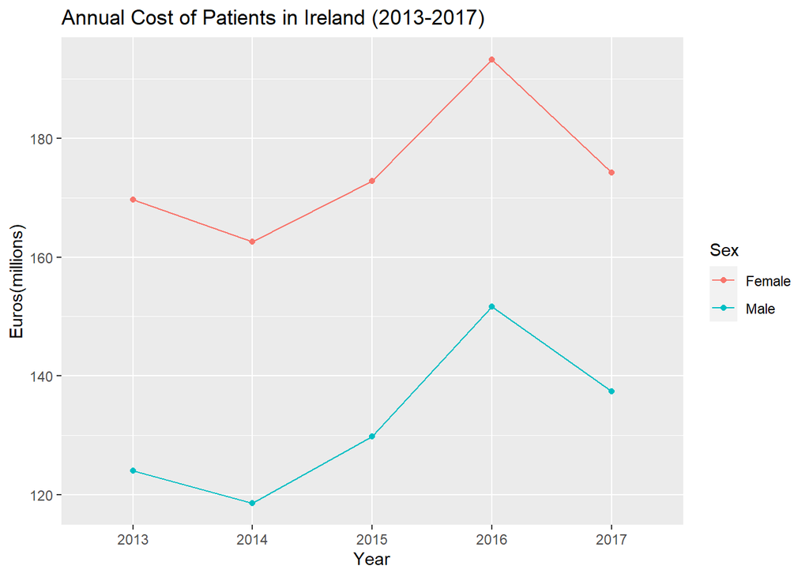

```r
# Load the package and plot the data giving appropriate labels and title
library(tidyverse)
graph <- ggplot(GPA05, aes(x = factor(Year), y = `Annual Cost (€ millions)`, colour = Sex, group = Sex)) + geom_line() + geom_point() + labs(x="Year", y="Euros(millions)", title="Annual Cost of Patients in Ireland (2013-2017)")
print(graph)
```

## Interpretation

Looking at the graph, we can clearly see that female patients have a higher annual cost as compared to male patients throughout the 5-year time span. Both the male and female annual patient costs decreased between 2013 and 2014, then increased over the next year. We can see that the costs increased greatly between 2015 and 2016 and then declined over the next year. The costs were the lowest in 2014 at 118.6 million and 162.6 million for male and female patients respectively. They were at their highest in 2016, peaking at 151.7 million and 193.3 million for males and females respectively.

## TASK 2 (R PACKAGE)

### Dataset

I obtained the data for BBC’s Top 100 Influential Women of 2020 via the given link:

https://github.com/rfordatascience/tidytuesday/blob/master/data/2020/2020-12-08/readme.md

The dataset gives us the name, category,role, country and description of all 100 women.

### Loading the data

```r
# Read the csv file
women <- read_csv('https://raw.githubusercontent.com/rfordatascience/tidytuesday/master/data/2020/2020-12-08/women.csv')
```

### SunburstR Package and its application

A package that I found very interesting was the ‘sunburstR’ package. The main purpose of this package is to generate sunburst plots.

Sunburst plots are used to represent nested or hierarchical data just like the dataset we are using for this part. In the case of my data set, individual women and their roles are nested in various categories they are being a part of (i.e., Leadership, Creativity, Identity and Knowledge). These are further nested into the countries they belong to. Sunburst plots help us easily visualize very complex data and retrieve a lot of useful information just with the help of a single plot.

### Manipulating and plotting the data

```r
# Install and load the R package
library(sunburstR)
```

I generated a vector ‘country_name’ that would assign a path for my sunburst plot. I used the following commands:

```r
# Generate a vector assigning the path for the sunburst plot

Country_name <- women %>%
    select(country, category, role, name) %>%
    # remove dash within dplyr pipe
  # mutate_at edits specific columns with a character vector or vars()
    mutate_at(vars(3, 4), funs(gsub("-", "", .))) %>%
    mutate(
        path = paste(country, category, role, name, sep = "-")
    ) %>%
    slice(2:100) %>%
    mutate(
        V2 = 1
    )
# Sunburst Plot for Top 100 women

sunburst(data = data.frame(xtabs(V2~path, Country_name)), legend = TRUE,
# Assign different colors to make the plot vibrant, I used 5 colors because the data is split into 5 categories
colors = c("#99cccc","#ffa97e", "#d21919","#137e17","#f2bd1b"))
```

[interactive chart not shown]

This compact plot beautifully represents this complex data in a way that is easily understandable, visually pleasing as well as engaging.

## TASK 3 (Functions/Programming)

I manipulated the same dataset i.e., women and named the new version women2. I got rid of the columns that I did not need using the following commands.

```r
# Loading a copy of the 'women' dataset

women2 <-  read_csv('https://raw.githubusercontent.com/rfordatascience/tidytuesday/master/data/2020/2020-12-08/women.csv')
#Manipulating the data to help carry out the analysis

women2 <- select(women2, c("category"))
```

I am using this specific column i.e., category because I want to calculate what percentage each category carries in the 2020 top 100 women worldwide. This way I can find out which categories are dominant in this particular year.

In order to carry out this analysis, I converted my character vector ‘category’ into a factor.

```r
#Convert the character vector to a factor

women2$category <- factor(women2$category, labels = c("All","Leadership","Creativity","Knowledge","Identity"), ordered = FALSE)
```

### Creating class

```r
#Create a class for the object
class(women2) <- "category_percentage"
```

### Assigning methods to the class

I assigned summary and plot methods to my class using the commands given below.

#### Summary Method

Summary method gives us a neat, easy to read table of the percentages of all the categories.

```r
#Summary method

summary.category_percentage <- function(x){
lapply(x, function(y) (table(y, dnn = NULL) / length(y))*100)
}
```

Now we will test whether our summary method give us a valid output.

```r
summary(women2)
```

```
## $category
##        All Leadership Creativity  Knowledge   Identity
##          1         21         17         32         29
```

Looking at the results, we can see that:

32% of the women are being recognized for Knowledge only.

1% of the women are being recognized for all 4 categories.

In 2020, the category ‘Knowledge’ is dominant i.e., majority of the top influential women are serving their roles in this particular stream. some examples of these roles include scientists, entrepreneurs, journalists, doctors etc.

#### Plot Method

This method allows us to easily generate a plot for our analysis.

```r
#Plot method
plot.category_percentage <- function(x){
par(mar = c(5, 5, 3, 3), mgp = c(2, 0.8, 0), las = 1)
barplot(height = table(x), xlab="Percentage", horiz=TRUE, col=7:8, las=1, main="Percentage of BBC Top 100 Women per category")
}
```

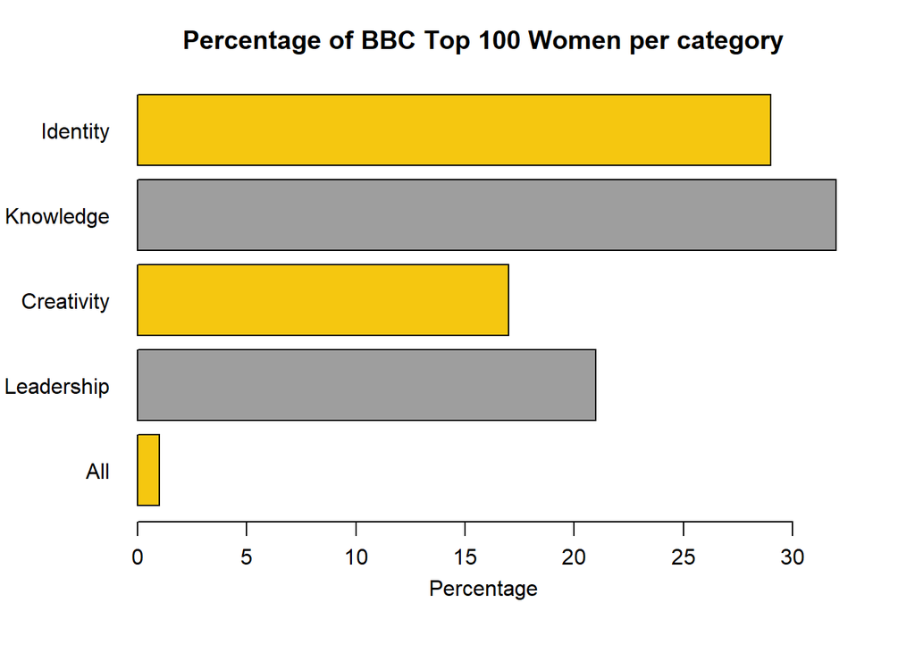

```r
#Plot
plot(women2)
```

The bar plot clearly represents the percentage of women in each category.